# Distributions

Maggy Critchlow

10/14/2020

## Required Packages and Data

```r
library(tidyverse)
library(RColorBrewer)
penguins <- read_csv("penguins.csv")
```

This week’s data is all about penguins.

```r
head(penguins)
```

```
## # A tibble: 6 x 8
##   species island bill_length_mm bill_depth_mm flipper_length_… body_mass_g sex
##   <chr>   <chr>           <dbl>         <dbl>            <dbl>       <dbl> <chr>
## 1 Adelie  Torge…           39.1          18.7              181        3750 male
## 2 Adelie  Torge…           39.5          17.4              186        3800 fema…
## 3 Adelie  Torge…           40.3          18                195        3250 fema…
## 4 Adelie  Torge…           NA            NA                 NA          NA <NA>
## 5 Adelie  Torge…           36.7          19.3              193        3450 fema…
## 6 Adelie  Torge…           39.3          20.6              190        3650 male
## # … with 1 more variable: year <dbl>
```

```r
summary(penguins)
```

```
##    species             island          bill_length_mm  bill_depth_mm
##  Length:344         Length:344         Min.   :32.10   Min.   :13.10
##  Class :character   Class :character   1st Qu.:39.23   1st Qu.:15.60
##  Mode  :character   Mode  :character   Median :44.45   Median :17.30
##                                        Mean   :43.92   Mean   :17.15
##                                        3rd Qu.:48.50   3rd Qu.:18.70
##                                        Max.   :59.60   Max.   :21.50
##                                        NA's   :2       NA's   :2
##  flipper_length_mm  body_mass_g       sex                 year
##  Min.   :172.0     Min.   :2700   Length:344         Min.   :2007
##  1st Qu.:190.0     1st Qu.:3550   Class :character   1st Qu.:2007
##  Median :197.0     Median :4050   Mode  :character   Median :2008
##  Mean   :200.9     Mean   :4202                      Mean   :2008
##  3rd Qu.:213.0     3rd Qu.:4750                      3rd Qu.:2009
##  Max.   :231.0     Max.   :6300                      Max.   :2009
##  NA's   :2         NA's   :2
```

These two commands are easy ways to check out the structure of the data and the variables within it. For the numeric variables, we’re able to peek at the five-number summary. These values for each variable could be visualized using a box plot, and depending on the questions that emerge from the data, these values could be separated by the categorical variables and compared. While this doesn’t offer the same objective evidence as statistical analysis, some interesting patterns and trends in the data can emerge from this. I’d like to find out if bill length varies by penguin species, and one way to answer this is with a color-coded density plot.

## Density Plot

```r
denselabels <- data.frame(species = c("Adelie", "Chinstrap", "Gentoo"), x = c(35, 55, 48), y = c(0.12, 0.10, 0.12))
```

R Graph Gallery had the great suggestion of adding text labels to the density curves, rather than just having a legend with corresponding colors. In order to add this using the `geom_text` line in ggplot, we need to create a data frame with the label of choice and their x and y coordinates. These can be layered directly onto the density plot.

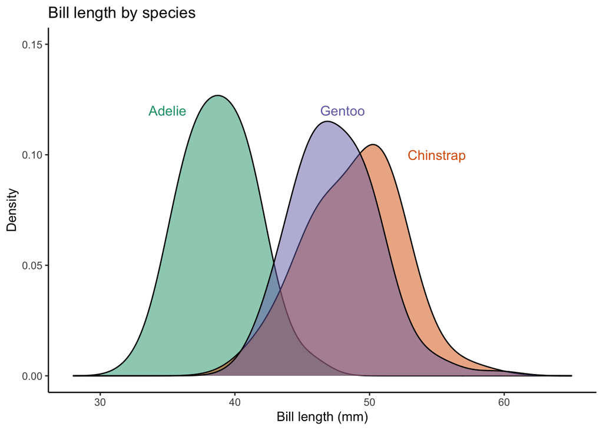

```r
plot1 <- ggplot() + geom_density(data = penguins, aes(x = bill_length_mm, group = species, fill = species), adjust=1.5, alpha=.5) + geom_text(data = denselabels, aes(x = x, y = y, label = species, color = species), size = 4) + xlim(28, 65) + ylim(0.00, 0.15) + scale_fill_brewer(palette = "Dark2") + scale_color_brewer(palette = "Dark2") + theme_classic() + theme(legend.position = "none") + labs(x = "Bill length (mm)", y = "Density", title = "Bill length by species")
plot1
```

### Discussion

One benefit of using the density curves is that we can get an idea of the shape of the data - for example, if the data follows a normal distribution, binomial, etc. This is important for statistical analysis, as some tests depend on the assumption that the data is normally distributed, and some models fit other patterns more effectively. In this case, all three of our species have a roughly normal distribution, with most penguins of each species having a similar bill length, and fewer penguins with a bill length that is much higher or lower than the average. This could indicate that these penguins are undergoing stabilized selection. The Adelie penguins tend to have shorter bills than the Gentoo and the Chinstrap penguins, and the latter two penguins are more similar to each other then the Adelie penguins. It would be interesting to compare the other physical measurements to see if this is true across the board. A bird’s beak also tends to offer clues to their diet, so comparing the preferred foods of each of these species could help to explain these patterns.

## Quantile-Quantile Plot and Normality

One method to assess normality is the quantile-quantile (Q-Q) plot, where the sample distribution of the data is plotted by a theoretically normal distribution. If the sample was perfectly normally distributed, the location of the points would be identical on both the sample and theoretical distributions, and the graph would show a perfectly straight, 45 degree line. Obviously, this perfect distribution rarely (if ever) exists in the real world, but the Q-Q plot can be used to determine how far the sample distribution deviates from normal.

### Histogram of Flipper Length

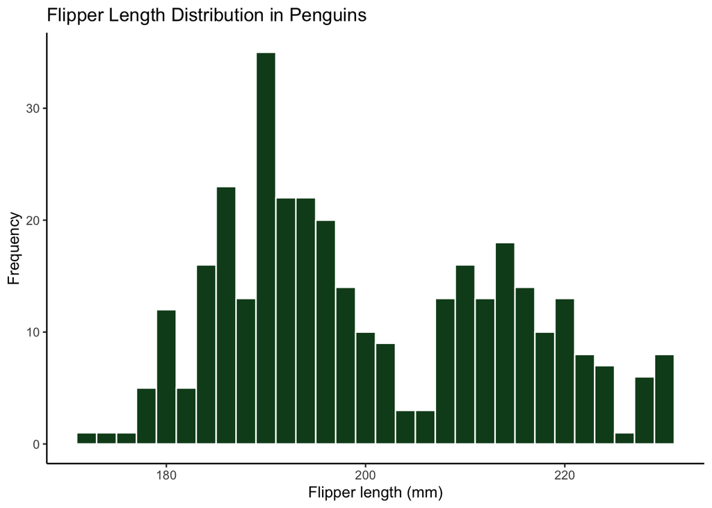

```r
plot2 <- ggplot() + geom_histogram(data = penguins, aes(x = flipper_length_mm), binwidth = 2, fill = "#104a20", color = "#ffffff") + theme_classic() + labs(x = "Flipper length (mm)", y = "Frequency", title = "Flipper Length Distribution in Penguins")
plot2
```

### Q-Q Plot of Flipper Length

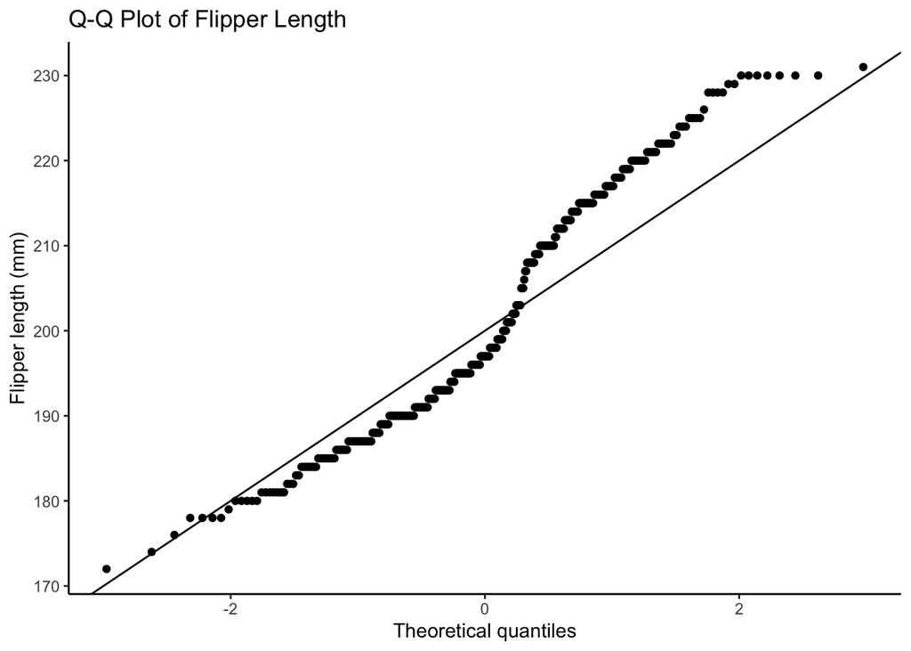

```r
qq <- qplot(sample = flipper_length_mm, data = penguins) + geom_abline(slope = 10, intercept = 200) + theme_classic() + labs(x = "Theoretical quantiles", y = "Flipper length (mm)", title = "Q-Q Plot of Flipper Length")
qq
```

### Discussion

This looks to me like there is some other distribution going on. As we can see in the histogram, higher frequencies occur with the shorter flipper lengths, and fewer penguins have longer flippers. While it’s normal (no pun intended) to see some deviation from the straight line at either extreme of the data set, the S-curve of this data set suggests non-normality. If I were going to analyze this data, I would first try grouping the penguins by sex, and seeing if the data is normally distributed within those groupings. Mathematically transforming the data can also help to correct some of these issues while keeping the patterns in the data intact. Some mathematical models can also handle non-normality without an issue, but it is important information to be aware of when running a statistical analysis on the data.